# Travel Package Purchase Prediction

## Model building - Boosting

### ADA Boost Classifier

```python
# adaboost classifier
abc = AdaBoostClassifier(random_state=1)

# fit the model on training set
abc.fit(X_train,y_train)
```

```
AdaBoostClassifier(random_state=1)
```

#### Checking the scores

```python
# check the scores on Training and Testing Datasets
abc_score = get_metrics_score(abc)
```

```
Accuracy on training set :  0.844463971880492
Accuracy on test set :  0.8381147540983607
Recall on training set :  0.29750778816199375
Recall on test set :  0.286231884057971
Precision on training set :  0.7047970479704797
Precision on test set :  0.6638655462184874
F1 on training set :  0.41840087623220146
F1 on test set :  0.39999999999999997
```

#### confusion matrix

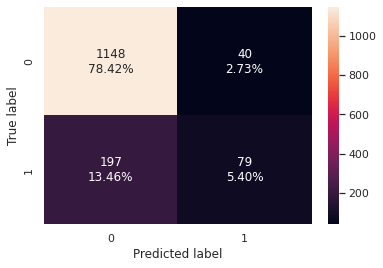

```python
# use draw_matrix function
draw_matrix(abc, X_test, y_test)
```

**Observations:**

### Hypertuned ADA Boost Classifier ( Model Performance Evaluation and Improvement-Boosting)

```python
# choose the type of classifier.
abc1 = AdaBoostClassifier(random_state=1)

# grid of parameters to choose from
parameters = {
    #let"s try different max_depth for base_estimator
    "base_estimator":[DecisionTreeClassifier(max_depth=1,random_state=1),DecisionTreeClassifier(max_depth=2,random_state=1),
                      DecisionTreeClassifier(max_depth=3,random_state=1)],
    "n_estimators": np.arange(10,60,10),
    "learning_rate": [0.05,0.15,0.45,0.75]
}

# type of scoring used to compare parameter  combinations
scorer = metrics.make_scorer(metrics.f1_score)

# run the grid search
grid_obj = GridSearchCV(abc1, parameters, scoring=scorer,cv=5)
grid_obj = grid_obj.fit(X_train, y_train)

# set the clf to the best combination of parameters
abcht = grid_obj.best_estimator_

# fit the best algorithm to the data.
abcht.fit(X_train, y_train)
```

```
AdaBoostClassifier(base_estimator=DecisionTreeClassifier(max_depth=3,
                                                         random_state=1),
                   learning_rate=0.45, random_state=1)
```

#### Checking the scores

```python
# check the scores on Training and Testing Datasets
abcht_score = get_metrics_score(abcht)
```

```
Accuracy on training set :  0.9065612185120093
Accuracy on test set :  0.8579234972677595
Recall on training set :  0.5809968847352025
Recall on test set :  0.4420289855072464
Precision on training set :  0.8817966903073287
Precision on test set :  0.6931818181818182
F1 on training set :  0.7004694835680751
F1 on test set :  0.5398230088495576
```

#### confusion matrix

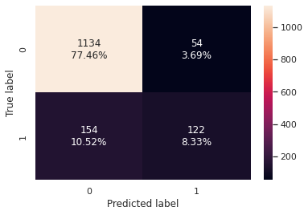

```python
# use draw_matrix function
draw_matrix(abcht, X_test, y_test)
```

**Observations:**

### Gradient Boost Classifier

```python
# gradient boost classifier
gbc = GradientBoostingClassifier(random_state=1)

# fit the model on training set
gbc.fit(X_train,y_train)
```

```
GradientBoostingClassifier(random_state=1)
```

#### Checking the scores

```python
# check the scores on Training and Testing Datasets
gbc_score = get_metrics_score(gbc)
```

```
Accuracy on training set :  0.877270064440539
Accuracy on test set :  0.8640710382513661
Recall on training set :  0.4236760124610592
Recall on test set :  0.39855072463768115
Precision on training set :  0.8473520249221184
Precision on test set :  0.7692307692307693
F1 on training set :  0.564901349948079
F1 on test set :  0.5250596658711217
```

#### confusion matrix

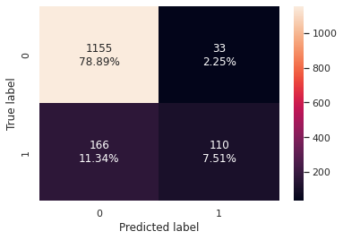

```python
# use draw_matrix function
draw_matrix(gbc, X_test, y_test)
```

**Observations:**

### Gradient Boost with ADA Boost Classifier (Model Performance Evaluation and Improvement-Boosting)

```python
# gradientboostclassifier with adaboost as init model
gbcab = GradientBoostingClassifier(init=AdaBoostClassifier(random_state=1),random_state=1)

# fit the model on training set
gbcab.fit(X_train,y_train)
```

```
GradientBoostingClassifier(init=AdaBoostClassifier(random_state=1),
                           random_state=1)
```

#### Checking the scores

```python
# check the scores on Training and Testing Datasets
gbcab_score = get_metrics_score(gbcab)
```

```
Accuracy on training set :  0.8804920913884007
Accuracy on test set :  0.8668032786885246
Recall on training set :  0.4392523364485981
Recall on test set :  0.42391304347826086
Precision on training set :  0.8545454545454545
Precision on test set :  0.7647058823529411
F1 on training set :  0.5802469135802469
F1 on test set :  0.5454545454545455
```

#### confusion matrix

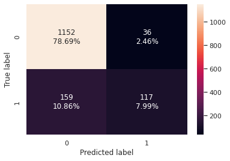

```python
# use draw_matrix function
draw_matrix(gbcab, X_test, y_test)
```

**Observations:**

### Hypertuned Gradient Boost Classifier(Model Performance Evaluation and Improvement-Boosting)

```python
# Choose the type of classifier.
gbcab1 = GradientBoostingClassifier(init=AdaBoostClassifier(random_state=1),random_state=1)

# Grid of parameters to choose from
parameters = {
    "n_estimators": np.arange(10,60,5),
    "subsample":[0.6,0.7,0.8],
    "max_features":[0.6,0.7,0.8],
    "learning_rate": [0.05,0.15,0.5]
}

# Type of scoring used to compare parameter combinations
scorer = metrics.make_scorer(metrics.f1_score)

# Run the grid search
grid_obj = GridSearchCV(gbcab1, parameters, scoring=scorer,cv=5)
grid_obj = grid_obj.fit(X_train, y_train)

# Set the clf to the best combination of parameters
gbcht = grid_obj.best_estimator_

# Fit the best algorithm to the data.
gbcht.fit(X_train, y_train)
```

```
GradientBoostingClassifier(init=AdaBoostClassifier(random_state=1),
                           learning_rate=0.5, max_features=0.6, n_estimators=50,
                           random_state=1, subsample=0.7)
```

#### Check the scores

```python
# check the scores on Training and Testing Datasets
gbcht_score = get_metrics_score(gbcht)
```

```
Accuracy on training set :  0.9036321031048623
Accuracy on test set :  0.8627049180327869
Recall on training set :  0.5841121495327103
Recall on test set :  0.4528985507246377
Precision on training set :  0.8581235697940504
Precision on test set :  0.7142857142857143
F1 on training set :  0.6950880444856349
F1 on test set :  0.5543237250554324
```

#### confusion matrix

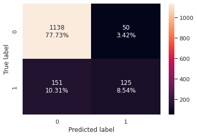

```python
# use draw_matrix function
draw_matrix(gbcht, X_test, y_test)
```

**Observations:**

### XG Boost Classifier (Extreme Gradient Boost Classifier)

```python
# xgbclassifier with eval_metric="logloss"
xgbc = XGBClassifier(random_state=1, eval_metric="logloss")

# fit the model on training set
xgbc.fit(X_train,y_train)
```

```
XGBClassifier(eval_metric='logloss', random_state=1)
```

#### Checking the scores

```python
# check the scores on Training and Testing Datasets
xgbc_score = get_metrics_score(xgbc)
```

```
Accuracy on training set :  0.8684827182190978
Accuracy on test set :  0.8558743169398907
Recall on training set :  0.3862928348909657
Recall on test set :  0.36231884057971014
Precision on training set :  0.8184818481848185
Precision on test set :  0.7407407407407407
F1 on training set :  0.5248677248677249
F1 on test set :  0.48661800486618
```

#### confusion matrix

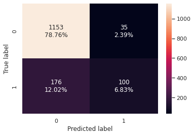

```python
# use draw_matrix function
draw_matrix(xgbc, X_test, y_test)
```

**Observations:**

### Hypertuned XG Boost Classifier (Model Performance Evaluation and Improvement-Boosting)

```python
# choose the classifier
xgbc1 = XGBClassifier(random_state=1, eval_metric="logloss")

# Grid of parameters to choose from
parameters = {
    "n_estimators": np.arange(10,60,10),
    "subsample":[0.6,0.7,0.8],
    "learning_rate":[0.1,0.3,0.55],
    "colsample_bytree":[0.5,0.7,0.9],
    "colsample_bylevel":[0.5,0.7,0.9]
}

# Type of scoring used to compare parameter combinations
scorer = metrics.make_scorer(metrics.f1_score)

# Run the grid search
grid_obj = GridSearchCV(xgbc1, parameters,scoring=scorer,cv=5)
grid_obj = grid_obj.fit(X_train, y_train)

# Set the clf to the best combination of parameters
xgbcht = grid_obj.best_estimator_

# Fit the best algorithm to the data.
xgbcht.fit(X_train, y_train)
```

```
XGBClassifier(colsample_bylevel=0.5, colsample_bytree=0.9,
              eval_metric='logloss', learning_rate=0.55, n_estimators=50,
              random_state=1, subsample=0.6)
```

#### Checking scores

```python
# check the scores on Training and Testing Datasets
xgbcht_score = get_metrics_score(xgbcht)
```

```
Accuracy on training set :  0.8910369068541301
Accuracy on test set :  0.860655737704918
Recall on training set :  0.5389408099688473
Recall on test set :  0.427536231884058
Precision on training set :  0.8199052132701422
Precision on test set :  0.7195121951219512
F1 on training set :  0.650375939849624
F1 on test set :  0.5363636363636364
```

#### confusion matrix

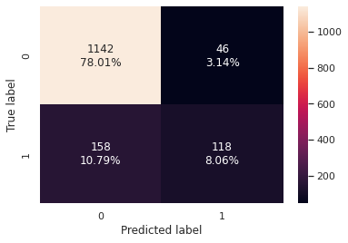

```python
# use draw_matrix function
draw_matrix(xgbcht, X_test, y_test)
```

**Observations:**

### Stacking Classifier

```python
# define the estimators for the model
estimators = [("Random Forest",rfcht),("ADA Boosting",abcht),("Decision Tree",dtc)]

# define the final estimator
final_estimator = xgbcht

# choose the classifier
sc= StackingClassifier(estimators=estimators,final_estimator=final_estimator)

# train the model on training set
sc.fit(X_train,y_train)
```

```
StackingClassifier(estimators=[('Random Forest',
                                RandomForestClassifier(class_weight={0: 0.15,
                                                                     1: 0.85},
                                                       max_features=0.7,
                                                       max_samples=0.3,
                                                       min_samples_leaf=5,
                                                       n_estimators=110,
                                                       random_state=1)),
                               ('ADA Boosting',
                                AdaBoostClassifier(base_estimator=DecisionTreeClassifier(max_depth=3,
                                                                                         random_state=1),
                                                   learning_rate=0.45,
                                                   random_state=1)),
                               ('Decision Tree',
                                DecisionTreeClassifier(class_weight={0: 0.15,
                                                                     1: 0.85},
                                                       random_state=1))],
                   final_estimator=XGBClassifier(colsample_bylevel=0.5,
                                                 colsample_bytree=0.9,
                                                 eval_metric='logloss',
                                                 learning_rate=0.55,
                                                 n_estimators=50,
                                                 random_state=1,
                                                 subsample=0.6))
```

#### Checking scores

```python
# check the scores on Training and Testing Datasets
sc_score = get_metrics_score(sc)
```

```
Accuracy on training set :  0.9651435266549502
Accuracy on test set :  0.880464480874317
Recall on training set :  0.8411214953271028
Recall on test set :  0.5905797101449275
Precision on training set :  0.9694793536804309
Precision on test set :  0.7244444444444444
F1 on training set :  0.9007506255212678
F1 on test set :  0.6506986027944112
```

#### confusion matrix

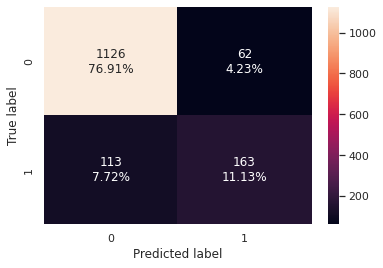

```python
# use draw_matrix function
draw_matrix(sc, X_test, y_test)
```

**Observations:**

## Compare all Models

```python
# defining list of models
models = [dtc, dtcht, bgc, bgclr, bgcdt, bgcht, rfc, rfcwt, rfcht, abc, abcht, gbc, gbcab, gbcht, xgbc, xgbcht, sc]

# defining empty lists to add train and test results
acc_train = []
acc_test = []
recall_train = []
recall_test = []
precision_train = []
precision_test = []
f1_train = []
f1_test = []

# looping through all the models to get the accuracy, f1, recall and precision scores
for model in models:
    j = get_metrics_score(model,False)
    acc_train.append(np.round(j[0],2))
    acc_test.append(np.round(j[1],2))
    recall_train.append(np.round(j[2],2))
    recall_test.append(np.round(j[3],2))
    precision_train.append(np.round(j[4],2))
    precision_test.append(np.round(j[5],2))
    f1_train.append(np.round(j[6],2))
    f1_test.append(np.round(j[7],2))

# create dataframe
comparison_frame = pd.DataFrame({"Model":["Decision Tree", "Decision Tree - Tuned", "Bagging", "Bagging - Tuned", "Bagging - Linear Regression",
                                          "Bagging - Decision Tree", "Random Forest", "Random Forest - Weights",
                                          "Random Forest - Tuned", "ADA Boost", "ADA Boost - Tuned", "Gradient Boost",
                                          "Gradient Boost - ADA Boost", "Gradient Boost - Tuned", "XG boost", "XG Boost - Tuned", "Stacking"],
                                          "Accuracy - Train": acc_train, "Accuracy - Test": acc_test,
                                          "Recall - Train": recall_train,"Recall - Test": recall_test,
                                          "Precision - Train": precision_train,"Precision - Test" :precision_test,
                                          "F1 - Train": f1_train,"F1 - Test": f1_test})
comparison_frame
```

|  | Model | Accuracy - Train | Accuracy - Test | Recall - Train | Recall - Test | Precision - Train | Precision - Test | F1 - Train | F1 - Test |
| --- | --- | --- | --- | --- | --- | --- | --- | --- | --- |
| 0 | Decision Tree | 1.00 | 0.89 | 1.00 | 0.68 | 1.00 | 0.71 | 1.00 | 0.69 |
| 1 | Decision Tree - Tuned | 0.67 | 0.65 | 0.83 | 0.79 | 0.34 | 0.32 | 0.49 | 0.46 |
| 2 | Bagging | 0.99 | 0.90 | 0.96 | 0.57 | 0.99 | 0.86 | 0.98 | 0.68 |
| 3 | Bagging - Tuned | 0.81 | 0.81 | 0.00 | 0.00 | 0.00 | 0.00 | 0.00 | 0.00 |
| 4 | Bagging - Linear Regression | 0.99 | 0.89 | 0.95 | 0.45 | 1.00 | 0.89 | 0.98 | 0.60 |
| 5 | Bagging - Decision Tree | 1.00 | 0.91 | 1.00 | 0.60 | 1.00 | 0.89 | 1.00 | 0.71 |
| 6 | Random Forest | 1.00 | 0.90 | 1.00 | 0.53 | 1.00 | 0.88 | 1.00 | 0.66 |
| 7 | Random Forest - Weights | 1.00 | 0.89 | 1.00 | 0.48 | 1.00 | 0.89 | 1.00 | 0.62 |
| 8 | Random Forest - Tuned | 0.88 | 0.83 | 0.71 | 0.59 | 0.67 | 0.55 | 0.69 | 0.57 |
| 9 | ADA Boost | 0.84 | 0.84 | 0.30 | 0.29 | 0.70 | 0.66 | 0.42 | 0.40 |
| 10 | ADA Boost - Tuned | 0.91 | 0.86 | 0.58 | 0.44 | 0.88 | 0.69 | 0.70 | 0.54 |
| 11 | Gradient Boost | 0.88 | 0.86 | 0.42 | 0.40 | 0.85 | 0.77 | 0.56 | 0.53 |
| 12 | Gradient Boost - ADA Boost | 0.88 | 0.87 | 0.44 | 0.42 | 0.85 | 0.76 | 0.58 | 0.55 |
| 13 | Gradient Boost - Tuned | 0.90 | 0.86 | 0.58 | 0.45 | 0.86 | 0.71 | 0.70 | 0.55 |
| 14 | XG boost | 0.87 | 0.86 | 0.39 | 0.36 | 0.82 | 0.74 | 0.52 | 0.49 |
| 15 | XG Boost - Tuned | 0.89 | 0.86 | 0.54 | 0.43 | 0.82 | 0.72 | 0.65 | 0.54 |
| 16 | Stacking | 0.97 | 0.88 | 0.84 | 0.59 | 0.97 | 0.72 | 0.90 | 0.65 |

**Observations:**

## Conclusion

1. A Key missing variable is if the Product pitched was the same product that was bought.
2. Basic and Deluxe are the most popular packages.
3. There was imbalance in data, as only 18% of customers bought any product. This must be fixed for future analysis.
4. NumberofChilden and NumberofPeoplevisiting does not seem to impact the performance of model a lot.
5. The company can run the model to achieve desired performance levels for new data, also to offer better packages to customers.
6. Young and single people are more likely to buy the offered packages.
7. Age and Income have a correlation and we see that higher age groups and higher Monthly Income groups lean towards the expensive packages.

## Business Recommendations & Insights

I have been able to build a predictive model:

1) that the company can used to identify customers who will be interested in purchasing the Travel package.

2) that the company can use to find the key factors that will have an impact on a customer taking a product or not.

- Company should help and promote customers to get a passport , as we see having a passport increases the chances of customer accepting a package.
- Most important features that have an impact on Product taken: Desgination, Passport,TierCity,Martialstatus,occupation
- Customers with Designation as Executive should be the target customers for the company .Customers who have passport and are from tier 3 city and are single or unmarried, have large business such customers have higher chances of taking new package.
- Mostly Single customers are accpeting a package , reason may be married couples might has kids , provding a property , with child care services can get married couples to accept the product.
- Customers monthly income in range of 10000- 30000, and age range 15-30, prefer 5 star properties also have higher chances of taking new package based on EDA.
- Based on EDA ,Factors from customer interaction data which can help in increasing the chances of the customer buying the travel package are:
  - Having a higher duration of pitch by salesman to the customer.
  - Getting a PitchSatisfactionScore of 3 or 5.
  - Having multiple follow ups with the customers.
1. The data shows customers with passport has higher buying ratio and business can curate international packages for such customers.
2. Specific packages can be created for different income groups.
3. The data collection process can be enhanced to capture additional information like customer satisfaction post tour and data to correlate the product pitched to the product actually purchased by customers.
4. The marketing team can curate the individual packages to the specific business designation.
5. The marketing team can create product and customer segment specific sale pitch to reduce the DurationOfPitch.
6. The TOURISM PACKAGE should be curated considering the features of existing packages that customers have purchased.
7. The company can run various campaigns and offers for customers with family to increase sales.